# Detección Bayesiana de un Efecto Débil con Apoyo de Priors Informativos

# 1 Introducción

En este ejercicio exploramos cómo la inferencia bayesiana, al incorporar conocimiento previo creíble, puede detectar un efecto real débil que un modelo clásico podría pasar por alto. Nos basamos en la literatura económica sobre el retorno de la educación.

## 1.1 Contexto del problema: Retornos de la educación

Supongamos que el retorno promedio por cada año adicional de educación formal se sitúa entre el 6% y el 10% en salarios. Es decir, el salario esperado crece en torno al 6–10% por año de educación:

El efecto en escala logarítmica sería:

$$\beta \approx \log(1.10) \approx 0.095$$

También se sabe que los datos de educación suelen tener error de medición de ±1 año, lo que introduce sesgos hacia cero (atenuación) en modelos clásicos.

# 2 Flujo de trabajo en inferencia bayesiana:

- Especificación del modelo generativo: verosimilitud y distribuciones a priori
- Chequeos a priori predictivos
- Estimación del modelo
- Evaluación de la convergencia del modelo: R-hat y ESS
- Chequeos predictivos posteriores
- Inferencia

## 2.1 Formulación del modelo generativo

Modelo bayesiano:

$$\log(wage_i) \sim \mathcal{N}(\alpha + \beta \cdot educ_i,\ \sigma^2)$$

Priors basados en la literatura:

$$\begin{aligned}
\alpha &\sim \mathcal{N}(7, 2^2) \\
\beta &\sim \mathcal{N}(0.095, 0.02^2) \\
\sigma &\sim \text{Cauchy}^+(0, .5)
\end{aligned}$$

- El prior para $\beta$ refleja que, antes de ver los datos, creemos que el retorno de la educación está **cercano al 9.5%**, y es poco probable que sea mucho mayor o menor (el intervalo de ±2 SD cubre aproximadamente entre 5.5% y 13.5%).
- Como hemos visto este prior **no fuerza** el resultado, pero sí **acentúa nuestra expectativa previa**, lo cual es útil si tenemos **muestras pequeñas** o **ruido considerable**.

## 2.2 Chequeo a priori predictivo (Prior predictive check)

## 2.3 Chequeo Predictivo A Priori

Antes de observar los datos, podemos simular resultados únicamente a partir de los priors especificados. Esto nos permite verificar si los valores que generan son plausibles en el contexto del problema (por ejemplo, log-salarios realistas).

## 2.4 Chequeo Predictivo A Priori (Modelo Completo)

Antes de ajustar el modelo, verificamos si las predicciones generadas **exclusivamente a partir de los priors** producen valores realistas de log-salario. Esto nos permite detectar si nuestros priors generan escenarios extremos o poco plausibles.

```r
prior_stan_code_2 <- "
data {
  int<lower=1> N;
  vector[N] educ;
}
generated quantities {
  real alpha = normal_rng(7, 2);
  real beta  = normal_rng(0.095, 0.02);
  real sigma = abs(cauchy_rng(0, .5));
  vector[N] log_wage_sim;
  for (i in 1:N) {
    log_wage_sim[i] = normal_rng(alpha + beta * educ[i], sigma);
  }
}
"

# Compile the prior model
prior_model_2 <- cmdstan_model(write_stan_file(prior_stan_code_2))
```

[output not shown]

[output not shown]

```r
# Simulate predictor values (education, as in note 2)
set.seed(123)
N_sim <- 30
educ_sim <- round(runif(N_sim, 8, 16))

# Sample from the prior predictive distribution
sim_prior_2 <- prior_model_2$sample(
  data = list(N = N_sim, educ = as.numeric(educ_sim)),
  fixed_param = TRUE,
  chains = 1,
  iter_sampling = 1000,
  seed = 123
)
```

[output not shown]

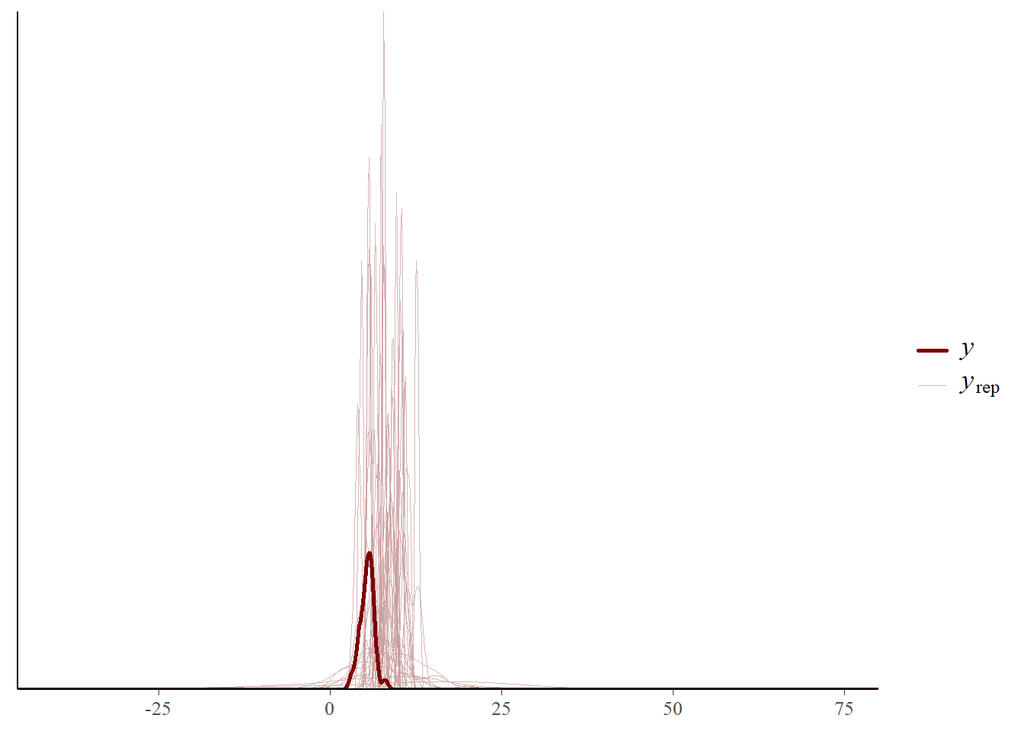

```r
# Extract draws matrix (rows = draws, cols = observations)
log_wage_sim_draws <- sim_prior_2$draws("log_wage_sim", format = "matrix")

# Use first draw as "observed" reference, next 50 as yrep
y_fake <- as.numeric(log_wage_sim_draws[1, ])
ppc_dens_overlay(y = y_fake, yrep = log_wage_sim_draws[1:50, ])
```

## 2.5 Código del Modelo en Stan

```r
stan_code <- "
data {
  int<lower=0> N;
  vector[N] log_wage;
  vector[N] educ;
}
parameters {
  real alpha;
  real beta;
  real<lower=0> sigma;
}
model {
  alpha ~ normal(7, 2);
  beta ~ normal(0.095, 0.02);
  sigma ~ cauchy(0, .5);
  log_wage ~ normal(alpha + beta * educ, sigma);
}
generated quantities {
  vector[N] log_wage_rep;
  for (i in 1:N) {
    log_wage_rep[i] = normal_rng(alpha + beta * educ[i], sigma);
  }
}
"
```

## 2.6 Ajuste del Modelo Bayesiano

```r
stan_data <- list(N = N, log_wage = data$log_wage, educ = data$educ_obs)
model <- cmdstan_model(write_stan_file(stan_code), cpp_options = list(stan_threads = TRUE))
```

[output not shown]

[output not shown]

```r
fit <- model$sample(
  data = stan_data,
  chains = 4,
  parallel_chains = 4,
  threads_per_chain = 2,
  iter_sampling = 2000,
  iter_warmup = 500,
  seed = 123
)
```

[output not shown]

```
## Chain 2 Informational Message: The current Metropolis proposal is about to be rejected because of the following issue:
```

[output not shown]

```
## Chain 2 If this warning occurs sporadically, such as for highly constrained variable types like covariance matrices, then the sampler is fine,
```

```
## Chain 2 but if this warning occurs often then your model may be either severely ill-conditioned or misspecified.
```

```
## Chain 2
```

[output not shown]

```r
fit$print(variables = c("alpha", "beta", "sigma"))
```

```
##  variable mean median   sd  mad   q5  q95 rhat ess_bulk ess_tail
##     alpha 7.16   7.16 0.22 0.21 6.79 7.51 1.00     3097     3505
##     beta  0.07   0.07 0.02 0.02 0.05 0.10 1.00     3122     3218
##     sigma 0.43   0.42 0.06 0.06 0.34 0.53 1.00     3041     3232
```

## 2.7 Chequeo Predictivo Posterior

Evaluamos si el modelo ajustado reproduce razonablemente bien los datos observados. Para ello, generamos réplicas de los datos (`log_wage`) a partir de la distribución posterior y las comparamos visualmente con los datos reales.

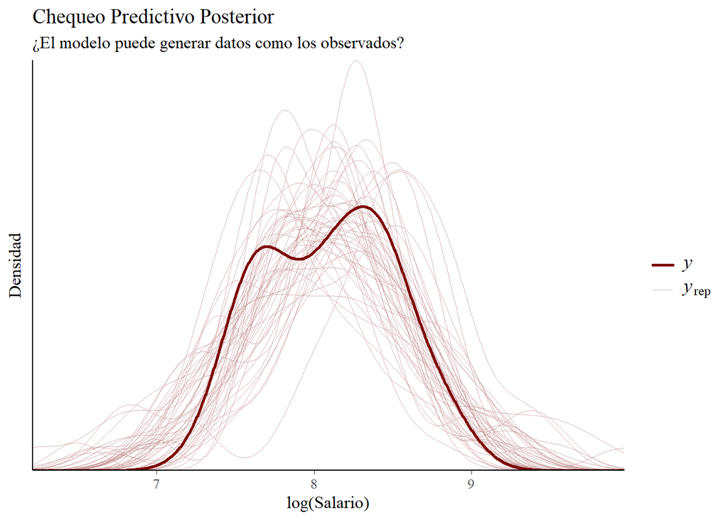

```r
# Extraer réplicas directamente del modelo (igual que nota 1)
log_wage_rep <- fit$draws(variables = "log_wage_rep", format = "matrix")

ppc_dens_overlay(y = data$log_wage, yrep = log_wage_rep[1:50, ]) +
  labs(
    title = "Chequeo Predictivo Posterior",
    subtitle = "¿El modelo puede generar datos como los observados?",
    x = "log(Salario)", y = "Densidad"
  )
```

## 2.8 Interpretación Numérica

```r
beta_draws <- fit$draws(variables = "beta", format = "df")
exp_beta <- exp(beta_draws$beta)
quantile(exp_beta, probs = c(0.025, 0.5, 0.975))
```

```
##     2.5%      50%    97.5%
## 1.044482 1.076586 1.111862
```

Este intervalo creíble muestra el crecimiento esperado del salario por cada año adicional de educación. Si el modelo clásico no detecta un efecto significativo, pero el modelo bayesiano sí, es evidencia del valor de incorporar priors basados en conocimiento previo.

## 2.9 Comparación con el Modelo Clásico

```r
lm_fit <- lm(log(wage) ~ educ_obs, data = data)
summary(lm_fit)
```

```
##
## Call:
## lm(formula = log(wage) ~ educ_obs, data = data)
##
## Residuals:
##      Min       1Q   Median       3Q      Max
## -0.69191 -0.25233  0.00353  0.22657  0.82528
##
## Coefficients:
##             Estimate Std. Error t value Pr(>|t|)
## (Intercept)  7.60590    0.32736  23.234   <2e-16 ***
## educ_obs     0.03874    0.02525   1.534    0.136
## ---
## Signif. codes:  0 '***' 0.001 '**' 0.01 '*' 0.05 '.' 0.1 ' ' 1
##
## Residual standard error: 0.4054 on 28 degrees of freedom
## Multiple R-squared:  0.07753,    Adjusted R-squared:  0.04458
## F-statistic: 2.353 on 1 and 28 DF,  p-value: 0.1362
```

## 2.10 Visualización Comparativa

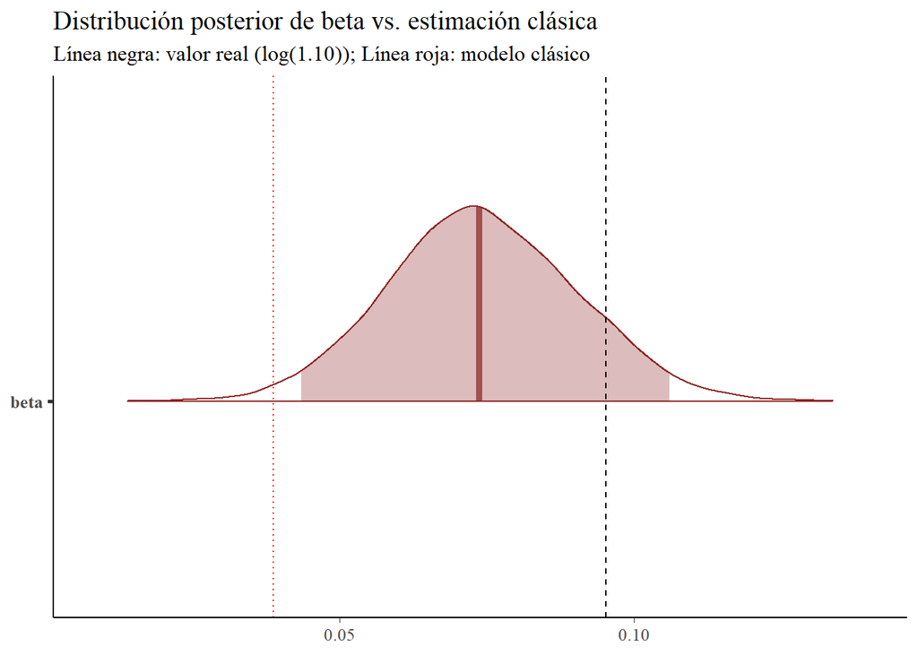

```r
ci_lm <- confint(lm_fit)["educ_obs", ]
point_lm <- coef(lm_fit)["educ_obs"]

mcmc_areas(beta_draws, pars = "beta", prob = 0.95) +
  vline_at(log(1.10), linetype = "dashed", color = "black") +
  vline_at(point_lm, linetype = "dotted", color = "red") +
  geom_segment(aes(x = ci_lm[1], xend = ci_lm[2], y = 0, yend = 0),
               color = "red", size = 1.5, inherit.aes = FALSE) +
  labs(title = "Distribución posterior de beta vs. estimación clásica",
       subtitle = "Línea negra: valor real (log(1.10)); Línea roja: modelo clásico")
```

# 3 Estimación con `brms()`

```r
#install.packages("brms")
library(brms)
```

## 3.1 Estimación Alternativa con `brms`

En esta sección repetimos el ajuste del modelo bayesiano, pero usando `brms`, que proporciona una interfaz más sencilla para definir modelos bayesianos con sintaxis tipo `lm`. Usamos los mismos priors informativos que en el modelo original.

Utilizamos los mismos priors:

Los guardamos en un objeto llamado priors

```r
 priors <- c(
  prior(normal(7, 2), class = "Intercept"),
  prior(normal(0.095, 0.02), class = "b"),
  prior(cauchy(0, .5), class = "sigma")
)
```

### 3.1.1 Chequeo predictivo a priori

```r
brms_priorcheck <- brm(
  formula = log(wage) ~ educ_obs,
  data    = data,
  family  = gaussian(),
  prior   = priors,
  seed    = 123,
  chains  = 4,
  cores   = 4,
  iter    = 2000,
  warmup  = 500,
  backend = "cmdstanr",
  sample_prior = "only"   # <-- solo esto cambia
)
```

[output not shown]

[output not shown]

[output not shown]

[output cut: 43 more lines]

[output not shown]

```r
pp_check(brms_priorcheck)
```

```
## Using 10 posterior draws for ppc type 'dens_overlay' by default.
```

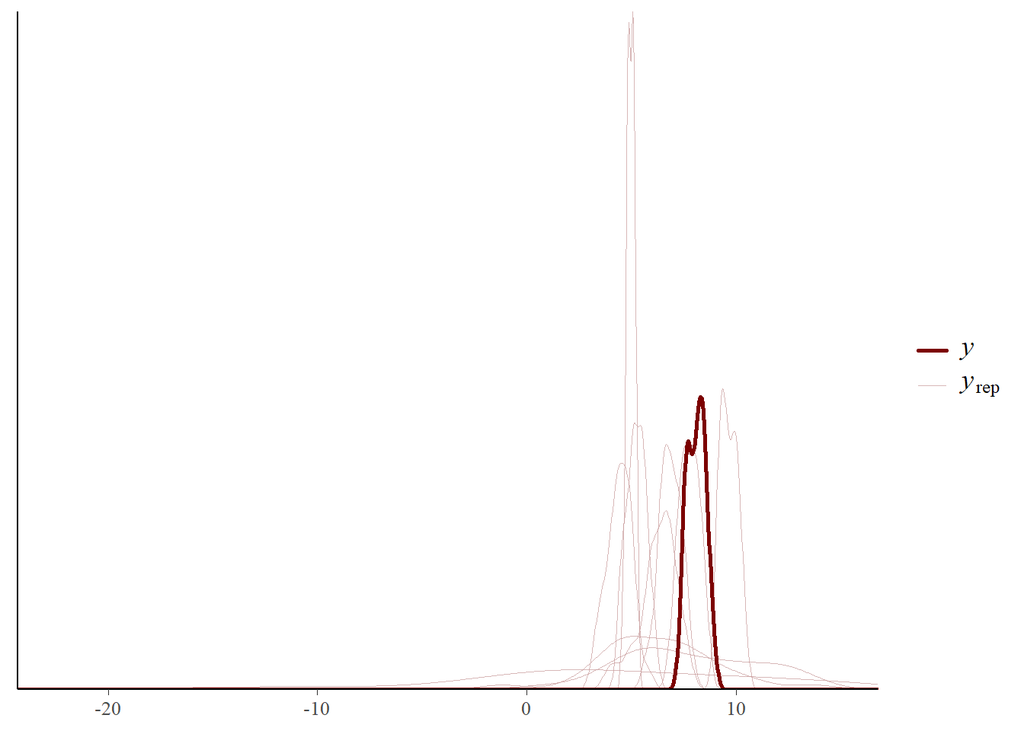

### 3.1.2 Estimación del modelo

```r
# Cargar la librería
library(brms)

brms_fit <- brm(
  formula = log(wage) ~ educ_obs,
  data = data,
  family = gaussian(),
  prior = priors,
  seed = 123,
  chains = 4,
  cores = 4,
  iter = 2000,
  warmup = 500,
  backend = "cmdstanr"
)
```

[output not shown]

[output cut: 43 more lines]

[output not shown]

## 3.2 Para extraer los resutlados de mi modelo

```r
brms_fit
```

```
##  Family: gaussian
##   Links: mu = identity; sigma = identity
## Formula: log(wage) ~ educ_obs
##    Data: data (Number of observations: 30)
##   Draws: 4 chains, each with iter = 2000; warmup = 500; thin = 1;
##          total post-warmup draws = 6000
##
## Regression Coefficients:
##           Estimate Est.Error l-95% CI u-95% CI Rhat Bulk_ESS Tail_ESS
## Intercept     7.16      0.22     6.72     7.57 1.00     5217     4586
## educ_obs      0.07      0.02     0.04     0.11 1.00     5044     4513
##
## Further Distributional Parameters:
##       Estimate Est.Error l-95% CI u-95% CI Rhat Bulk_ESS Tail_ESS
## sigma     0.43      0.06     0.33     0.56 1.00     4204     4190
##
## Draws were sampled using sample(hmc). For each parameter, Bulk_ESS
## and Tail_ESS are effective sample size measures, and Rhat is the potential
## scale reduction factor on split chains (at convergence, Rhat = 1).
```

Para obtener las gráficas de las cadenas de Marcov, simplemente hacemos lo siguiente con `plot()`:

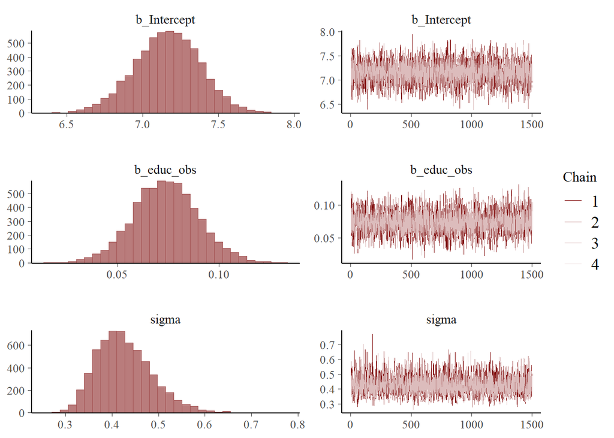

```r
plot(brms_fit)
```

Para hacer el chequeo predictivo posterior. Simplemente usamos `pp_check()`

```r
pp_check(brms_fit)
```

```
## Using 10 posterior draws for ppc type 'dens_overlay' by default.
```

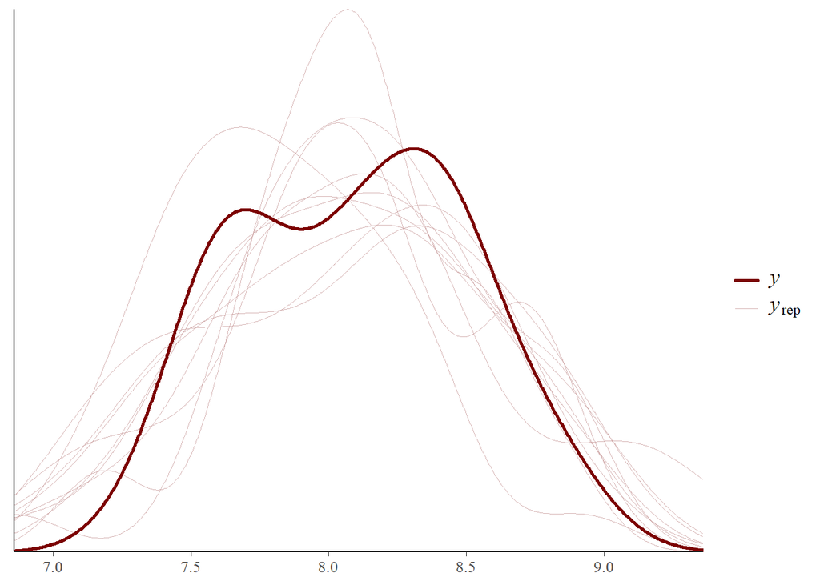

### 3.2.1 Modelos BRMS con funcion lognormal (sin necesidad de transformar)

```r
# Cargar la librería
library(brms)

priors <- c(
  prior(normal(7, 2), class = "Intercept"),
  prior(normal(0.095, 0.02), class = "b"),
  prior(cauchy(0, .5), class = "sigma")
)

brms_fit2 <- brm(
  formula = wage ~ educ_obs,
  data = data,
  family = lognormal(), #Aquí el cambio clave
  prior = priors,
  seed = 123,
  chains = 4,
  cores = 4,
  iter = 2000,
  warmup = 500,
  backend = "cmdstanr"
)
```

[output not shown]

[output cut: 43 more lines]

[output not shown]

```r
brms_fit2
```

```
##  Family: lognormal
##   Links: mu = identity; sigma = identity
## Formula: wage ~ educ_obs
##    Data: data (Number of observations: 30)
##   Draws: 4 chains, each with iter = 2000; warmup = 500; thin = 1;
##          total post-warmup draws = 6000
##
## Regression Coefficients:
##           Estimate Est.Error l-95% CI u-95% CI Rhat Bulk_ESS Tail_ESS
## Intercept     7.16      0.22     6.71     7.58 1.00     5175     4203
## educ_obs      0.07      0.02     0.04     0.11 1.00     5491     4077
##
## Further Distributional Parameters:
##       Estimate Est.Error l-95% CI u-95% CI Rhat Bulk_ESS Tail_ESS
## sigma     0.43      0.06     0.33     0.56 1.00     4687     4331
##
## Draws were sampled using sample(hmc). For each parameter, Bulk_ESS
## and Tail_ESS are effective sample size measures, and Rhat is the potential
## scale reduction factor on split chains (at convergence, Rhat = 1).
```

Para hacer el chequeo predictivo posterior. Simplemente usamos `pp_check()`. NOTA: Usar lognormal() tiene la ventaja de que transforma los chequeos predictivos posteriores:

```r
pp_check(brms_fit2)
```

```
## Using 10 posterior draws for ppc type 'dens_overlay' by default.
```

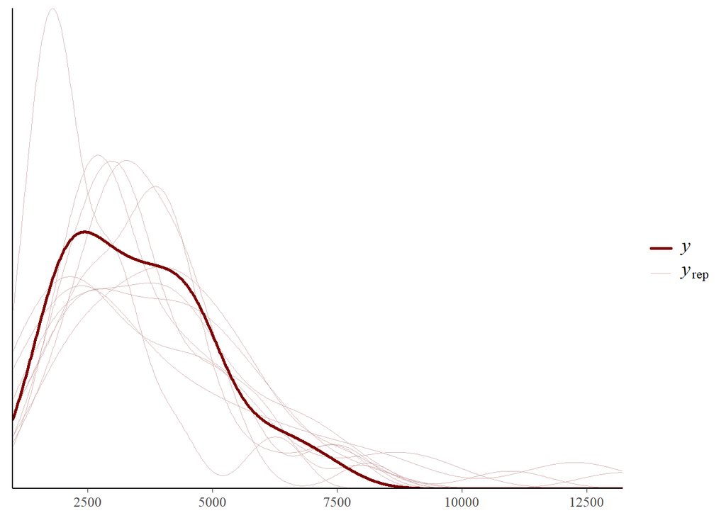

## 3.3 Comparar posterior con línea negra (valor real), y estimación clásica en rojo

Para ello convertimos el objeto brms_fit (que contiene las muestras posteriores del modelo ajustado con brms) en un data frame compatible con la librería posterior, que se puede usar para graficar con bayesplot.

Después se grafica la distribución posterior del coeficiente de educación (b_educ_obs) como un área sombreada.

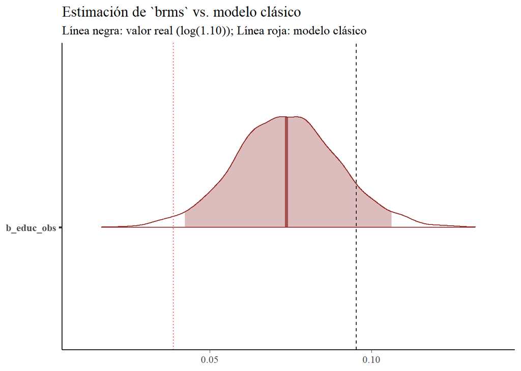

```r
posterior_samples <- as_draws_df(brms_fit)

mcmc_areas(posterior_samples, pars = "b_educ_obs", prob = 0.95) +
  vline_at(log(1.10), linetype = "dashed", color = "black") +
  vline_at(point_lm, linetype = "dotted", color = "red") +
  geom_segment(aes(x = ci_lm[1], xend = ci_lm[2], y = 0, yend = 0),
               color = "red", size = 1.5, inherit.aes = FALSE) +
  labs(title = "Estimación de `brms` vs. modelo clásico",
       subtitle = "Línea negra: valor real (log(1.10)); Línea roja: modelo clásico")
```

## 3.4 Comparación brms y stan en crudo

Primero extraemos las muestras de beta del modelo cmdstanr. Después, hacemos lo mismo para b_educ_obs del modelo brms. Finalmente, calculamos los intervalos creíbles al 95%.

```r
beta_cmdstanr <- fit$draws(variables = "beta", format = "df")$beta
beta_brms <- posterior_samples$b_educ_obs

interval_cmdstanr <- quantile(beta_cmdstanr, probs = c(0.025, 0.5, 0.975))
interval_brms <- quantile(beta_brms, probs = c(0.025, 0.5, 0.975))

# Construir tabla
tibble(
  Modelo = c("cmdstanr", "brms"),
  `2.5%` = c(interval_cmdstanr[1], interval_brms[1]),
  `Mediana` = c(interval_cmdstanr[2], interval_brms[2]),
  `97.5%` = c(interval_cmdstanr[3], interval_brms[3])
)
```

```
## # A tibble: 2 × 4
##   Modelo   `2.5%` Mediana `97.5%`
##   <chr>     <dbl>   <dbl>   <dbl>
## 1 cmdstanr 0.0435  0.0738   0.106
## 2 brms     0.0423  0.0737   0.106
```

## 3.5 Discusión Final

- ¿Por qué el modelo bayesiano puede detectar un efecto que el modelo clásico no?
- ¿Qué papel jugó el prior en este caso?
- ¿Qué pasa si usamos una prior más débil (por ejemplo, `beta ~ normal(0, 1)`)?